# Sistem Persamaan Linier

Sistem persamaan linear (atau sistem linear) adalah himpunan persamaan linear.

Sistem linear homogen adalah himpunan persamaan linear homogen.

Saat menampilkan sistem persamaan $m$ dengan variabel $n$ tidak diketahui $x_1, x_2, \ldots, x_n$, Biasanya, kita menulis setiap persamaan dalam bentuk standar dan menyelaraskan suku-suku yang bersesuaian dari setiap persamaan ke dalam kolom.

$$ \begin{aligned} a_{11}x_1 & \quad + \quad a_{12}x_2 & \quad + \cdots + \quad a_{1n}x_n & \quad = \quad b_1 \\ a_{21}x_1 & \quad + \quad a_{22}x_2 & \quad + \cdots + \quad a_{2n}x_n & \quad = \quad b_2 \\ & \quad \vdots & \quad \vdots & \quad \vdots \\ a_{m1}x_1 & \quad + \quad a_{m2}x_2 & \quad + \cdots + \quad a_{mn}x_n & \quad = \quad b_m \end{aligned} $$

dengan demikian, sistem homogen biasanya ditulis sebagai:

$$ \begin{aligned} a_{11}x_1 & \quad + \quad a_{12}x_2 & \quad + \cdots + \quad a_{1n}x_n & \quad = \quad 0 \\ a_{21}x_1 & \quad + \quad a_{22}x_2 & \quad + \cdots + \quad a_{2n}x_n & \quad = \quad 0 \\ & \quad \vdots & \quad \vdots & \quad \vdots \\ a_{m1}x_1 & \quad + \quad a_{m2}x_2 & \quad + \cdots + \quad a_{mn}x_n & \quad = \quad 0 \end{aligned} $$

### Apa Itu Sistem Persamaan Linear?

Sistem persamaan linier atau linear system adalah kumpulan dua atau lebih persamaan linier yang melibatkan variabel yang sama, dan tujuan kita adalah mencari nilai variabel yang bisa memenuhi semua persamaan secara bersamaan.

Contoh sederhana dari sistem persamaan linier:

\begin{cases} 2x + y = 5\\ x - 3y = 1 \end{cases}

Ini adalah dua persamaan yang melibatkan dua variabel x dan y.

## Solusi persamaan linear

$$a_1x_1 + a_2x_2 + \cdots + a_nx_n = b$$

adalah $n$-tupel $(s_1, s_2, \ldots, s_n)$ bilangan real yang membuat penugasan variabel $x_1 = s_1, x_2 = s_2, \ldots, x_n = s_n$ memenuhi persamaan. Kita katakan $(s_1, \ldots, s_n)$ *menyelesaikan persamaan* dalam kasus ini.

## Solusi sistem persamaan linear

*Solusi sistem persamaan linear*

$$ \begin{aligned} a_{11}x_1 & \quad + \quad a_{12}x_2 & \quad + \cdots + \quad a_{1n}x_n & \quad = \quad b_1 \\ a_{21}x_1 & \quad + \quad a_{22}x_2 & \quad + \cdots + \quad a_{2n}x_n & \quad = \quad b_2 \\ & \quad \vdots & \quad \vdots & \quad \vdots \\ a_{m1}x_1 & \quad + \quad a_{m2}x_2 & \quad + \cdots + \quad a_{mn}x_n & \quad = \quad b_m \end{aligned} $$

adalah $n$-tupel $(s_1, s_2, \ldots, s_n)$ yang merupakan solusi untuk setiap $m$ persamaan dalam sistem. Kita katakan $(s_1, s_2, \ldots, s_n)$ *menyelesaikan sistem* dalam kasus ini.

## Jenis-Jenis Himpunan Solusi

Diberikan sistem linear, kita mencari himpunan *semua* solusi sistem. Himpunan solusi ini akan memiliki salah satu dari tiga bentuk kualitatif:

1. *Himpunan solusi kosong* (tidak ada solusi). Kita katakan sistem *inkonsisten. Jika tidak, sistem disebut **konsisten*.
2. *Himpunan solusi mengandung satu elemen* (tepat satu solusi).
3. *Himpunan solusi mengandung tak hingga banyak elemen* (tak hingga banyak solusi).

# Contoh 1.1.6. Solusi sistem elementer

Untuk setiap sistem, hitung himpunan solusinya.

## Sistem 1

$$ \begin{aligned} x - y &= 0 \\ x - y &= 1 \end{aligned} $$

## Sistem 2

$$ \begin{aligned} x - y &= 0 \\ x + y &= 1 \end{aligned} $$

## Sistem 3

$$ \begin{aligned} x - y &= 1 \\ 2x - 2y &= 2 \end{aligned} $$

## Solusi

### Sistem 1: *Tidak Ada Solusi (Inkonsisten)*

Persamaan $x - y = 0$ dan $x - y = 1$ bertentangan. Ekspresi yang sama tidak bisa sama dengan 0 dan 1 secara bersamaan.

- *Himpunan solusi:* $\emptyset$ (himpunan kosong)
- *Klasifikasi:* Sistem inkonsisten

### Sistem 2: *Solusi Unik*

Menjumlahkan persamaan:

- $(x - y) + (x + y) = 0 + 1$
- $2x = 1$
- $x = \frac{1}{2}$

Substitusi kembali:

- $\frac{1}{2} - y = 0$
- $y = \frac{1}{2}$
- *Himpunan solusi:* $\left\{\left(\frac{1}{2}, \frac{1}{2}\right)\right\}$
- *Klasifikasi:* Konsisten dengan solusi unik

### Sistem 3: *Tak Hingga Banyak Solusi*

Persamaan kedua adalah 2 kali persamaan pertama:

- $2x - 2y = 2$ ekuivalen dengan $x - y = 1$

Misalkan $y = t$ (parameter bebas), maka:

- $x = 1 + t$
- *Himpunan solusi:* $\{(1+t, t) : t \in \mathbb{R}\}$
- *Klasifikasi:* Konsisten dengan tak hingga banyak solusi

## Interpretasi Geometris

Persamaan linear (nontrivial) dalam dua variabel tak diketahui mendefinisikan sebuah *garis di $\mathbb{R}^2$, dan persamaan (nontrivial) dalam tiga variabel tak diketahui mendefinisikan sebuah **bidang di $\mathbb{R}^3$*.

Observasi ini memungkinkan kita membawa intuisi geometris yang kuat untuk analisis sistem persamaan linear dalam dua atau tiga variabel tak diketahui.

1. Contoh Solusi Tunggal

Hanya ada satu solusi

Sistem Persamaan

\begin{cases} x + y = 5 \\ x - y = 1 \end{cases}

Penyelesaian

Jumlahkan kedua persamaan:

[ \begin{aligned} (x+y) + (x-y) &= 5 + 1 \\ 2x &= 6 \\ x &= 3 \end{aligned} ]

Substitusi ke persamaan pertama:

[ \begin{aligned} 3 + y &= 5 \\ y &= 2 \end{aligned} ]

### Hasil

(x, y) = (3, 2)

Solusi tunggal, karena hanya ada satu pasangan nilai yang memenuhi kedua persamaan.

2. Contoh Tidak Ada Solusi (Sistem Inkonsisten)

Tidak ada nilai variabel yang memenuhi semua persamaan

Sistem Persamaan

\begin{cases} x + y = 2 \\ x + y = 5 \end{cases}

Analisis

Persamaan kiri sama

Hasil kanan berbeda

Artinya:

2 tidak sama dengan 5

Ini mustahil, karena satu jumlah tidak bisa bernilai dua angka berbeda.

Kesimpulan

- Tidak ada solusi
- Sistem ini disebut inkonsisten
3. Contoh Solusi Tak Terhingga (Sistem Dependen)

Ada banyak (tak terhingga) solusi

Sistem Persamaan

\begin{cases} x + y = 4 \\ 2x + 2y = 8 \end{cases}

Analisis

Persamaan kedua adalah:

2(x + y = 4)

Artinya kedua persamaan sebenarnya sama.

Penyelesaian

Dari:

[ \begin{aligned} x + y &= 4 \\ y &= 4 - x \end{aligned} ]

Contoh solusi:

(0,4), (1,3), (2,2), (3,1),...

Kesimpulan

Sistem ini memiliki tak terhingga banyaknya solusi dan disebut sistem dependen.

```python
!pip install numpy sympy
```

```python
import sys
print(sys.executable)
```

```
F:\kal\venv\Scripts\python.exe
```

```python
import numpy as np

A = np.array([[2, 1, -1],
              [-3, -1, 2],
              [-2, 1, 2]], dtype=float)
b = np.array([8, -11, -3], dtype=float)

x = np.linalg.solve(A, b)
print("Solusi x, y, z:", x)
```

```
Solusi x, y, z: [ 2.  3. -1.]
```

Verifikasi Solusi

Kita periksa apakah ini benar

\begin{bmatrix} x = 2 \\ y = 3 \\ z = -1 \end{bmatrix} ]

memenuhi sistem persamaan:

[ \begin{cases} 2x + y - z = 8 \\ -3x - y + 2z = -11 \\ -2x + y + 2z = -3 \end{cases} ]

Persamaan (1)

[ \begin{aligned} 2(2) + 3 - (-1) &= 4 + 3 + 1 \\ &= 8 \end{aligned} ]

Sesuai dengan ruas kanan.

Persamaan (2)

[ \begin{aligned} -3(2) - 3 + 2(-1) &= -6 - 3 - 2 \\ &= -11 \end{aligned} ]

Sesuai dengan ruas kanan.

Persamaan (3)

[ \begin{aligned} -2(2) + 3 + 2(-1) &= -4 + 3 - 2 \\ &= -3 \end{aligned} ]

Sesuai dengan ruas kanan.

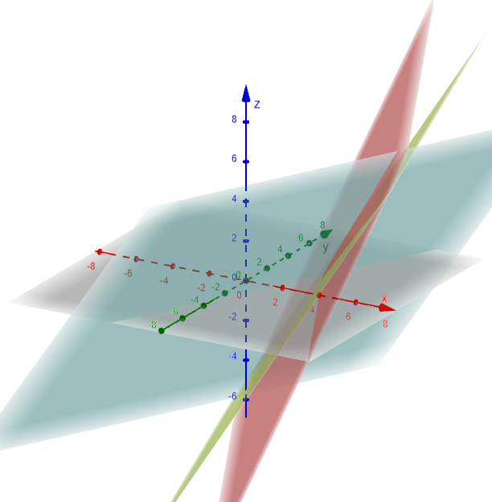

```python
from IPython.display import Image
Image("tugas1.png")
```